# Tarefa1

Rafael Gustavo Furlan, Ricardo Squassina Lee

• Explore as rotinas Exemplo Rede.R e Exemplo Rede Two Mode.R . Rode os códigos na plataforma R utilizando como base as tabelas Rede One Mode_Tarefa Aula 1_Paulista T4.xlsx e Rede Two Mode_Tarefa Aula 1_Paulista T4.xlsx. (atenção: não são as mesmas bases trabalhadas em sala).

• Faça pequenas modificações na tabela e veja seus resultados.

• Inclua outras análises em seu código (usando as extensões sna, network ou igraph) e comente os resultados (seja criativo!).

• Compile as saídas dos códigos (conteúdo das variáveis, gráficos, tabelas) em um documento Word (usando o modelo deste documento) e comente seus resultados (principalmente as medidas de centralidade), análises, potenciais implicações gerenciais, etc, conforme discutido em sala na Aula 1.

• Desafio: Baseado na tabela da Rede Two Mode desta tarefa, faça uma análise de agrupamento (cluster analysis) do tipo hierárquico aglomerativo (dendrograma) das pessoas ou dos produtos adquiridos por elas, levando em consideração apenas a estrutura de relações entre elas. Comente como implementou e discuta os resultados, comparando com a rede construída. Utilize a plataforma R e o script de exemplo de uso de Cluster Analysis em R.

Dica: após a seleção dos grupos, desenhe a rede e represente os nós das pessoas (ou produtos) com cores de acordo com o grupo correspondente.

Lendo os arquivos

```r
# carregando os arquivos
#Rede_One_Mode <- read_excel("Rede One Mode_Tarefa Aula 1_Paulista T4.xlsx")
#Rede_Two_Mode <- read_excel("Rede Two Mode_Tarefa Aula 1_Paulista T4.xlsx")
Rede_One_Mode <- read.csv(file = "Rede One Mode_Tarefa Aula 1_Paulista T4.csv",
                          header = TRUE)
Rede_Two_Mode <- read.csv(file = "Rede Two Mode_Tarefa Aula 1_Paulista T4.csv",
                          encoding = "UTF-8",
                          header = TRUE)
```

Explore as rotinas Exemplo Rede.R e Exemplo Rede Two Mode.R . Rode os códigos na plataforma R utilizando como base as tabelas Rede One Mode_Tarefa Aula 1_Paulista T4.xlsx e Rede Two Mode_Tarefa Aula 1_Paulista T4.xlsx. (atenção: não são as mesmas bases trabalhadas em sala).

```r
# explorando Rede One Mode
Rede_One_Mode
```

| ï..Label | A | B | C | D | E | F | G | H | I | J | K | L | M | N | O | P |
| --- | --- | --- | --- | --- | --- | --- | --- | --- | --- | --- | --- | --- | --- | --- | --- | --- |
| A | 0 | 1 | 1 | 1 | 0 | 0 | 0 | 0 | 0 | 1 | 1 | 0 | 1 | 1 | 1 | 1 |
| B | 1 | 0 | 1 | 1 | 0 | 0 | 0 | 0 | 0 | 1 | 1 | 0 | 0 | 0 | 1 | 1 |
| C | 1 | 1 | 0 | 1 | 0 | 0 | 0 | 0 | 0 | 0 | 1 | 0 | 1 | 1 | 0 | 1 |
| D | 1 | 1 | 1 | 0 | 1 | 0 | 0 | 0 | 0 | 1 | 0 | 0 | 0 | 1 | 1 | 0 |
| E | 0 | 0 | 0 | 1 | 0 | 1 | 1 | 1 | 1 | 1 | 1 | 0 | 1 | 0 | 0 | 1 |
| F | 0 | 0 | 0 | 0 | 1 | 0 | 1 | 0 | 0 | 0 | 1 | 0 | 0 | 0 | 0 | 0 |
| G | 0 | 0 | 0 | 0 | 1 | 1 | 0 | 0 | 1 | 1 | 1 | 0 | 1 | 0 | 0 | 0 |
| H | 0 | 0 | 0 | 0 | 1 | 0 | 0 | 0 | 1 | 1 | 0 | 0 | 0 | 0 | 0 | 0 |
| I | 0 | 0 | 0 | 0 | 1 | 0 | 1 | 1 | 0 | 0 | 1 | 1 | 1 | 0 | 0 | 0 |
| J | 1 | 1 | 0 | 1 | 1 | 0 | 1 | 1 | 0 | 0 | 1 | 0 | 1 | 1 | 0 | 1 |

[output cut: 6 more lines]

```r
grede_one_mode <- Rede_One_Mode[,2:17]
grede_one_mode
```

| A | B | C | D | E | F | G | H | I | J | K | L | M | N | O | P |
| --- | --- | --- | --- | --- | --- | --- | --- | --- | --- | --- | --- | --- | --- | --- | --- |
| 0 | 1 | 1 | 1 | 0 | 0 | 0 | 0 | 0 | 1 | 1 | 0 | 1 | 1 | 1 | 1 |
| 1 | 0 | 1 | 1 | 0 | 0 | 0 | 0 | 0 | 1 | 1 | 0 | 0 | 0 | 1 | 1 |
| 1 | 1 | 0 | 1 | 0 | 0 | 0 | 0 | 0 | 0 | 1 | 0 | 1 | 1 | 0 | 1 |
| 1 | 1 | 1 | 0 | 1 | 0 | 0 | 0 | 0 | 1 | 0 | 0 | 0 | 1 | 1 | 0 |
| 0 | 0 | 0 | 1 | 0 | 1 | 1 | 1 | 1 | 1 | 1 | 0 | 1 | 0 | 0 | 1 |
| 0 | 0 | 0 | 0 | 1 | 0 | 1 | 0 | 0 | 0 | 1 | 0 | 0 | 0 | 0 | 0 |
| 0 | 0 | 0 | 0 | 1 | 1 | 0 | 0 | 1 | 1 | 1 | 0 | 1 | 0 | 0 | 0 |
| 0 | 0 | 0 | 0 | 1 | 0 | 0 | 0 | 1 | 1 | 0 | 0 | 0 | 0 | 0 | 0 |
| 0 | 0 | 0 | 0 | 1 | 0 | 1 | 1 | 0 | 0 | 1 | 1 | 1 | 0 | 0 | 0 |
| 1 | 1 | 0 | 1 | 1 | 0 | 1 | 1 | 0 | 0 | 1 | 0 | 1 | 1 | 0 | 1 |

[output cut: 6 more lines]

```r
rownames(grede_one_mode) <- Rede_One_Mode[,1]
grede_one_mode
```

|  | A | B | C | D | E | F | G | H | I | J | K | L | M | N | O | P |
| --- | --- | --- | --- | --- | --- | --- | --- | --- | --- | --- | --- | --- | --- | --- | --- | --- |
| A | 0 | 1 | 1 | 1 | 0 | 0 | 0 | 0 | 0 | 1 | 1 | 0 | 1 | 1 | 1 | 1 |
| B | 1 | 0 | 1 | 1 | 0 | 0 | 0 | 0 | 0 | 1 | 1 | 0 | 0 | 0 | 1 | 1 |
| C | 1 | 1 | 0 | 1 | 0 | 0 | 0 | 0 | 0 | 0 | 1 | 0 | 1 | 1 | 0 | 1 |
| D | 1 | 1 | 1 | 0 | 1 | 0 | 0 | 0 | 0 | 1 | 0 | 0 | 0 | 1 | 1 | 0 |
| E | 0 | 0 | 0 | 1 | 0 | 1 | 1 | 1 | 1 | 1 | 1 | 0 | 1 | 0 | 0 | 1 |
| F | 0 | 0 | 0 | 0 | 1 | 0 | 1 | 0 | 0 | 0 | 1 | 0 | 0 | 0 | 0 | 0 |
| G | 0 | 0 | 0 | 0 | 1 | 1 | 0 | 0 | 1 | 1 | 1 | 0 | 1 | 0 | 0 | 0 |
| H | 0 | 0 | 0 | 0 | 1 | 0 | 0 | 0 | 1 | 1 | 0 | 0 | 0 | 0 | 0 | 0 |
| I | 0 | 0 | 0 | 0 | 1 | 0 | 1 | 1 | 0 | 0 | 1 | 1 | 1 | 0 | 0 | 0 |
| J | 1 | 1 | 0 | 1 | 1 | 0 | 1 | 1 | 0 | 0 | 1 | 0 | 1 | 1 | 0 | 1 |

[output cut: 6 more lines]

```r
print("sna::degree")
```

```
[1] "sna::degree"
```

```r
sna::degree(grede_one_mode,gmode="graph",cmode="indegree")
```

```
 [1]  9  7  7  7  9  3  6  3  6 10 11  1  8  7  7  7
```

```r
print("sna::closeness")
```

```
[1] "sna::closeness"
```

```r
sna::closeness(grede_one_mode,gmode="graph")
```

```
 [1] 0.6818182 0.6250000 0.6000000 0.6250000 0.7142857 0.5357143
 [7] 0.6250000 0.5172414 0.6250000 0.7142857 0.7894737 0.3947368
[13] 0.6818182 0.6250000 0.6000000 0.6250000
```

```r
print("sna::betweenness")
```

```
[1] "sna::betweenness"
```

```r
sna::betweenness(grede_one_mode,gmode="graph")
```

```
 [1]  1.953846  1.010989  1.371429  2.079121 13.177289  0.000000
 [7]  1.733333  0.400000 15.307692 10.481685 18.699634  0.000000
[13]  6.323443  1.010989  1.371429  2.079121
```

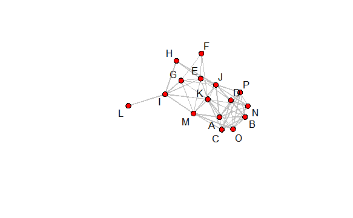

```r
gplot(grede_one_mode,gmode="graph",displaylabels = TRUE,edge.col="gray",usearrows=FALSE)
```

```r
#gplot3d(grede_one_mode)
```

```r
# Explorando Rede Two Mode
Rede_Two_Mode
```

| X.U.FEFF. | iPhone | iPad | Livro.Harry.Potter | jogo.MineCraft | Camisa.do.Corinthians | Bola.de.Futebol | Flauta.Transversal | Lista.Telefônica | Caixa.de.Fósforos | Calculadora | Detergente |
| --- | --- | --- | --- | --- | --- | --- | --- | --- | --- | --- | --- |
| João | 1 | 1 | 0 | 1 | 1 | 0 | 1 | 1 | 1 | 1 | 0 |
| Maria | 1 | 1 | 1 | 1 | 1 | 1 | 1 | 1 | 1 | 1 | 1 |
| José | 0 | 0 | 0 | 0 | 1 | 0 | 1 | 0 | 0 | 1 | 0 |
| Paulo | 1 | 0 | 0 | 0 | 1 | 0 | 0 | 0 | 0 | 1 | 0 |
| Pedro | 0 | 0 | 1 | 0 | 1 | 1 | 0 | 1 | 1 | 1 | 0 |
| Luisa | 0 | 0 | 1 | 0 | 1 | 1 | 0 | 1 | 1 | 1 | 0 |
| Marcelo | 1 | 0 | 0 | 0 | 0 | 1 | 1 | 0 | 0 | 1 | 0 |
| Alfredo | 0 | 1 | 1 | 0 | 1 | 1 | 1 | 0 | 0 | 1 | 0 |
| Joaquim | 1 | 0 | 1 | 0 | 1 | 1 | 1 | 1 | 1 | 1 | 0 |
| Gabriela | 0 | 1 | 1 | 1 | 1 | 1 | 0 | 1 | 1 | 0 | 0 |

[output cut: 5 more lines]

```r
grede_two_mode <- Rede_Two_Mode[,2:12]
grede_two_mode
```

| iPhone | iPad | Livro.Harry.Potter | jogo.MineCraft | Camisa.do.Corinthians | Bola.de.Futebol | Flauta.Transversal | Lista.Telefônica | Caixa.de.Fósforos | Calculadora | Detergente |
| --- | --- | --- | --- | --- | --- | --- | --- | --- | --- | --- |
| 1 | 1 | 0 | 1 | 1 | 0 | 1 | 1 | 1 | 1 | 0 |
| 1 | 1 | 1 | 1 | 1 | 1 | 1 | 1 | 1 | 1 | 1 |
| 0 | 0 | 0 | 0 | 1 | 0 | 1 | 0 | 0 | 1 | 0 |
| 1 | 0 | 0 | 0 | 1 | 0 | 0 | 0 | 0 | 1 | 0 |
| 0 | 0 | 1 | 0 | 1 | 1 | 0 | 1 | 1 | 1 | 0 |
| 0 | 0 | 1 | 0 | 1 | 1 | 0 | 1 | 1 | 1 | 0 |
| 1 | 0 | 0 | 0 | 0 | 1 | 1 | 0 | 0 | 1 | 0 |
| 0 | 1 | 1 | 0 | 1 | 1 | 1 | 0 | 0 | 1 | 0 |
| 1 | 0 | 1 | 0 | 1 | 1 | 1 | 1 | 1 | 1 | 0 |
| 0 | 1 | 1 | 1 | 1 | 1 | 0 | 1 | 1 | 0 | 0 |

[output cut: 5 more lines]

```r
rownames(grede_two_mode) <- Rede_Two_Mode[,1]
print("sna::degree")
```

```
[1] "sna::degree"
```

```r
sna::degree(grede_two_mode,gmode="twomode",cmode="indegree")
```

```
 [1]  8 11  3  3  6  6  4  6  8  7  4  6  3  8  6  7  6  9  5 13 10  9
[23] 10  9  9  2
```

```r
print("sna::closeness")
```

```
[1] "sna::closeness"
```

```r
sna::closeness(grede_two_mode,gmode="twomode")
```

```
 [1] 0.5555556 0.6410256 0.4385965 0.4385965 0.5102041 0.5102041
 [7] 0.4545455 0.4901961 0.5555556 0.5319149 0.4545455 0.5102041
[13] 0.3846154 0.5555556 0.5102041 0.4901961 0.4716981 0.5319149
[19] 0.4545455 0.6410256 0.5555556 0.5319149 0.5555556 0.5319149
[25] 0.5319149 0.4098361
```

```r
print("sna::betweenness")
```

```
[1] "sna::betweenness"
```

```r
sna::betweenness(grede_two_mode,gmode="twomode")
```

```
 [1] 31.841411 89.083242  2.029950  2.532392 11.714679 11.714679
 [7]  5.136318 12.241745 25.300294 18.405570  6.296868 12.023228
[13]  5.705013 25.175721 12.798892 26.387388 10.194285 30.358487
[19]  8.844409 89.770501 38.863806 36.500161 47.969415 38.313380
[25] 41.961685  2.836483
```

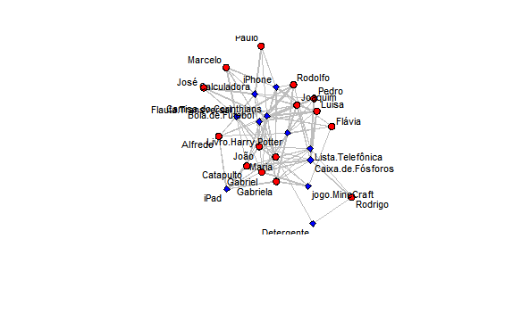

```r
gplot(grede_two_mode,gmode="twomode",displaylabels = TRUE,
      edge.col="gray",label.cex = 0.7,usearrows=FALSE)
```

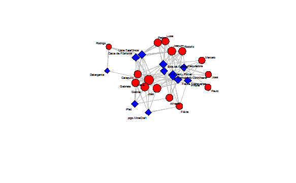

```r
# Aprimorando a representacao da rede
gplot(grede_two_mode,gmode="twomode",displaylabels = TRUE,
      edge.col="gray",label.cex = 0.4,usearrows=FALSE,
      vertex.cex = sna::closeness(grede_two_mode,gmode="twomode")*4)
```

```r
#gplot3d(grede_two_mode,gmode = "twomode")
```

Faça pequenas modificações na tabela e veja seus resultados.

```r
grede_one_mode_a <- grede_one_mode
grede_one_mode_a$A <- 1
grede_one_mode_a
```

|  | A | B | C | D | E | F | G | H | I | J | K | L | M | N | O | P |
| --- | --- | --- | --- | --- | --- | --- | --- | --- | --- | --- | --- | --- | --- | --- | --- | --- |
| A | 1 | 1 | 1 | 1 | 0 | 0 | 0 | 0 | 0 | 1 | 1 | 0 | 1 | 1 | 1 | 1 |
| B | 1 | 0 | 1 | 1 | 0 | 0 | 0 | 0 | 0 | 1 | 1 | 0 | 0 | 0 | 1 | 1 |
| C | 1 | 1 | 0 | 1 | 0 | 0 | 0 | 0 | 0 | 0 | 1 | 0 | 1 | 1 | 0 | 1 |
| D | 1 | 1 | 1 | 0 | 1 | 0 | 0 | 0 | 0 | 1 | 0 | 0 | 0 | 1 | 1 | 0 |
| E | 1 | 0 | 0 | 1 | 0 | 1 | 1 | 1 | 1 | 1 | 1 | 0 | 1 | 0 | 0 | 1 |
| F | 1 | 0 | 0 | 0 | 1 | 0 | 1 | 0 | 0 | 0 | 1 | 0 | 0 | 0 | 0 | 0 |
| G | 1 | 0 | 0 | 0 | 1 | 1 | 0 | 0 | 1 | 1 | 1 | 0 | 1 | 0 | 0 | 0 |
| H | 1 | 0 | 0 | 0 | 1 | 0 | 0 | 0 | 1 | 1 | 0 | 0 | 0 | 0 | 0 | 0 |
| I | 1 | 0 | 0 | 0 | 1 | 0 | 1 | 1 | 0 | 0 | 1 | 1 | 1 | 0 | 0 | 0 |
| J | 1 | 1 | 0 | 1 | 1 | 0 | 1 | 1 | 0 | 0 | 1 | 0 | 1 | 1 | 0 | 1 |

[output cut: 6 more lines]

```r
sna::degree(grede_one_mode_a,gmode="graph",cmode="indegree")
```

```
 [1] 15  7  7  7  9  3  6  3  6 10 11  1  8  7  7  7
```

```r
sna::closeness(grede_one_mode_a,gmode="graph")
```

```
 [1] 1.0000000 0.6521739 0.6521739 0.6521739 0.7500000 0.5769231
 [7] 0.6521739 0.5769231 0.6521739 0.7500000 0.7894737 0.5357143
[13] 0.6818182 0.6521739 0.6521739 0.6521739
```

```r
sna::betweenness(grede_one_mode_a,gmode="graph")
```

```
 [1] 12.6519231  0.9340659  1.3714286  1.7252747 10.2112637  0.0000000
 [7]  1.4916667  0.2833333 10.4455128  8.0432234 13.4855311  0.0000000
[13]  4.3260073  0.9340659  1.3714286  1.7252747
```

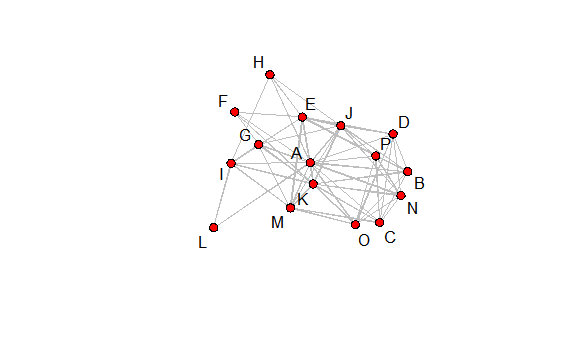

```r
gplot(grede_one_mode_a,gmode="graph",displaylabels = TRUE,edge.col="gray",usearrows=FALSE)
```

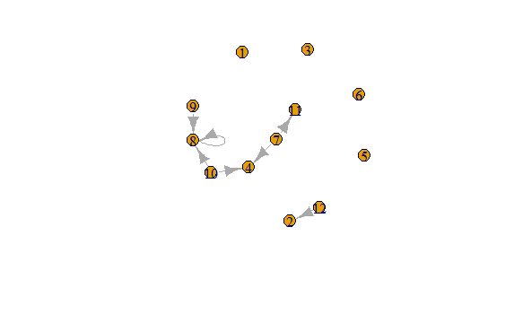

```r
grede_two_mode_a <- make_graph(edges = c(grede_one_mode$A--grede_one_mode$B++grede_one_mode$C--grede_one_mode$D--grede_one_mode$E--grede_one_mode$F--grede_one_mode$G--grede_one_mode$H--grede_one_mode$I--grede_one_mode$J--grede_one_mode$K--grede_one_mode$L--grede_one_mode$M--grede_one_mode$N--grede_one_mode$O--grede_one_mode$P)+1,n = 5)
plot(grede_two_mode_a,gmode = "twomode")
```

```r
######################### igraph - One-Mode
# gera a um objeto graph
g1 <- graph.adjacency(as.matrix(grede_one_mode), weighted=NULL, mode = "directed")
summary(g1)
```

```
IGRAPH 6ffb5ba DN-- 16 108 --
+ attr: name (v/c)
```

```r
layout1 <- layout.fruchterman.reingold(g1)
layout2 <- layout.circle(g1)
layout3 <- layout.sphere(g1)
layout4 <- layout.random(g1)
layout5 <- layout.reingold.tilford(g1)
```

```
At structural_properties.c:3338 :graph contains a cycle, partial result is returned
```

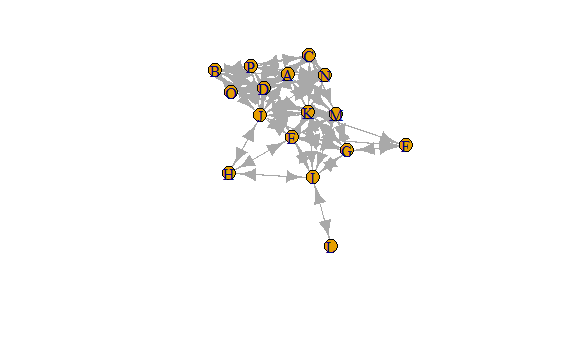

```r
layout6 <- layout.kamada.kawai(g1)
layout7 <- layout.lgl(g1)
# plot a gragh using the parameters in the layout
plot(g1, layout=layout1)
```

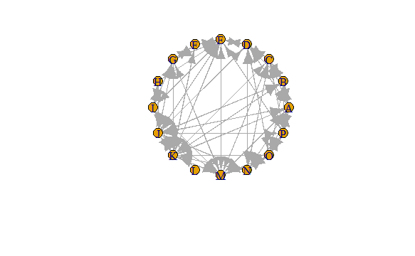

```r
plot(g1, layout=layout2)
```

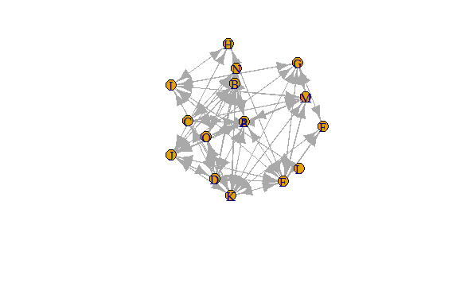

```r
plot(g1, layout=layout3)
```

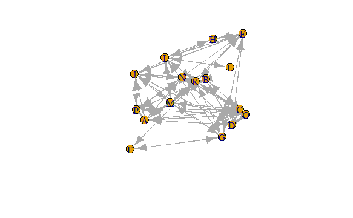

```r
plot(g1, layout=layout4)
```

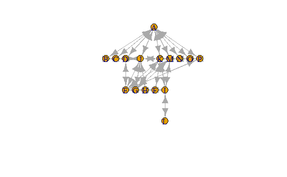

```r
plot(g1, layout=layout5)
```

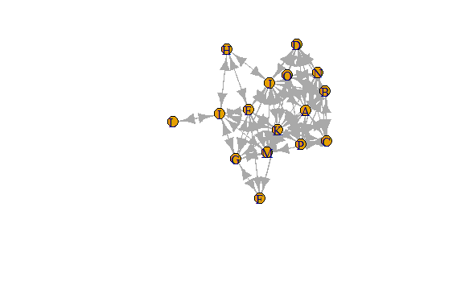

```r
plot(g1, layout=layout6)
```

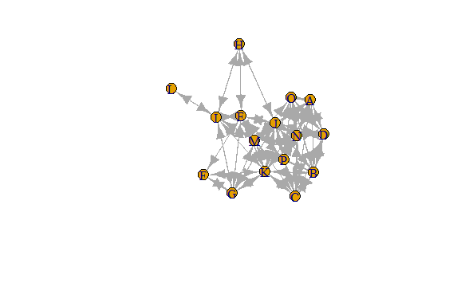

```r
plot(g1, layout=layout7)
```

```r
######################### igraph - Two-Mode
# gera a um objeto graph
g2 <- graph_from_incidence_matrix(data.matrix(grede_two_mode))
summary(g2)
```

```
IGRAPH 74a82cb UN-B 26 89 --
+ attr: type (v/l), name (v/c)
```

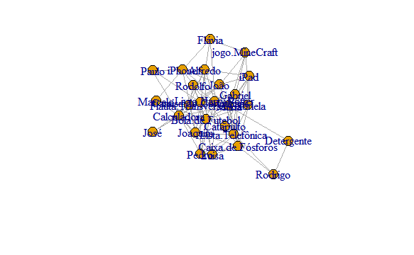

```r
layout1 <- layout.fruchterman.reingold(g2)
layout2 <- layout.circle(g2)
layout3 <- layout.sphere(g2)
layout4 <- layout.random(g2)
layout5 <- layout.reingold.tilford(g2)
layout6 <- layout.kamada.kawai(g2)
layout7 <- layout.lgl(g2)
# plot a gragh using the parameters in the layout
plot(g2, layout=layout1)
```

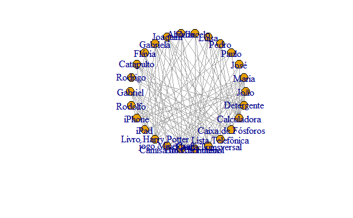

```r
plot(g2, layout=layout2)
```

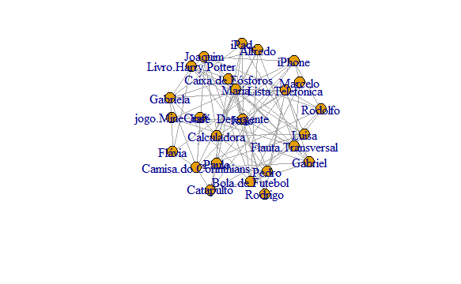

```r
plot(g2, layout=layout3)
```

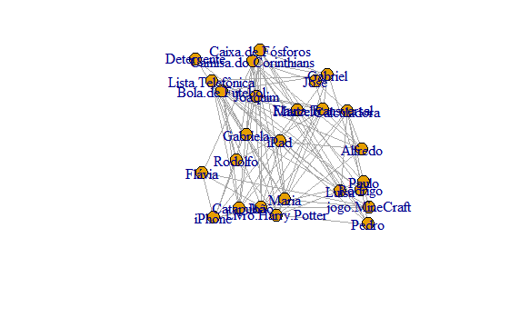

```r
plot(g2, layout=layout4)
```

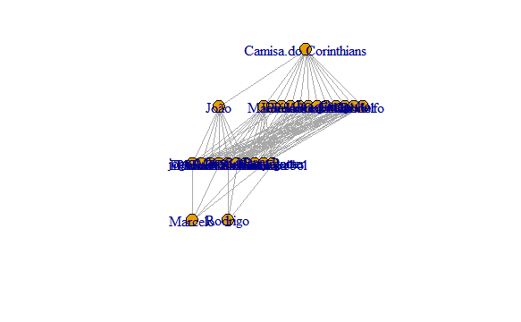

```r
plot(g2, layout=layout5)
```

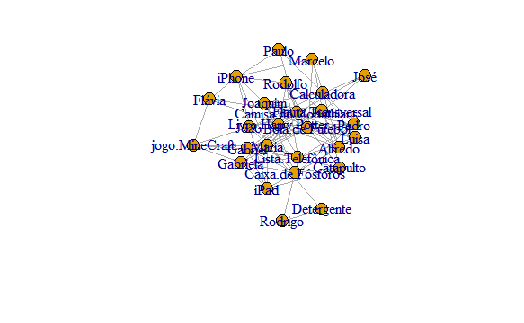

```r
plot(g2, layout=layout6)
```

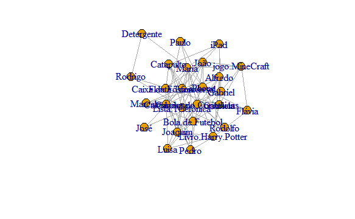

```r
plot(g2, layout=layout7)
```

Compile as saídas dos códigos (conteúdo das variáveis, gráficos, tabelas) em um documento Word (usando o modelo deste documento) e comente seus resultados (principalmente as medidas de centralidade), análises, potenciais implicações gerenciais, etc, conforme discutido em sala na Aula 1.

One-Mode

```r
# Explorando a rede
sna::degree(grede_one_mode,gmode="graph",cmode="indegree")
```

```
 [1]  9  7  7  7  9  3  6  3  6 10 11  1  8  7  7  7
```

```r
sna::closeness(grede_one_mode,gmode="graph")
```

```
 [1] 0.6818182 0.6250000 0.6000000 0.6250000 0.7142857 0.5357143
 [7] 0.6250000 0.5172414 0.6250000 0.7142857 0.7894737 0.3947368
[13] 0.6818182 0.6250000 0.6000000 0.6250000
```

```r
sna::betweenness(grede_one_mode,gmode="graph")
```

```
 [1]  1.953846  1.010989  1.371429  2.079121 13.177289  0.000000
 [7]  1.733333  0.400000 15.307692 10.481685 18.699634  0.000000
[13]  6.323443  1.010989  1.371429  2.079121
```

```r
sna::bicomponent.dist(grede_one_mode) # retorna os bicomponentes de um gráfico de entrada, juntamente com a distribuição de tamanho e as informações de associação.
```

```
$members
$members$`1`
 [1]  1  2  3  4  5  6  7  8  9 10 11 13 14 15 16


$membership
 [1]  1  1  1  1  1  1  1  1  1  1  1 NA  1  1  1  1

$csize
 1
15

$cdist
 1  2  3  4  5  6  7  8  9 10 11 12 13 14 15 16
 0  0  0  0  0  0  0  0  0  0  0  0  0  0  1  0
```

```r
sna::bicomponent.dist(grede_one_mode, symmetrize = c("strong", "weak"))
```

```
$members
$members$`1`
 [1]  1  2  3  4  5  6  7  8  9 10 11 13 14 15 16


$membership
 [1]  1  1  1  1  1  1  1  1  1  1  1 NA  1  1  1  1

$csize
 1
15

$cdist
 1  2  3  4  5  6  7  8  9 10 11 12 13 14 15 16
 0  0  0  0  0  0  0  0  0  0  0  0  0  0  1  0
```

```r
sna::components(grede_one_mode,connected="weak")
```

```
[1] 1
```

```r
sna::components(grede_one_mode,connected="strong")
```

```
Node 1, Reach 16, Total 16
Node 2, Reach 16, Total 32
Node 3, Reach 16, Total 48
Node 4, Reach 16, Total 64
Node 5, Reach 16, Total 80
Node 6, Reach 16, Total 96
Node 7, Reach 16, Total 112
Node 8, Reach 16, Total 128
Node 9, Reach 16, Total 144
Node 10, Reach 16, Total 160
Node 11, Reach 16, Total 176
Node 12, Reach 16, Total 192
Node 13, Reach 16, Total 208
Node 14, Reach 16, Total 224
Node 15, Reach 16, Total 240
Node 16, Reach 16, Total 256
[1] 1
```

```r
sna::cug.test(grede_one_mode,gtrans,cmode="size")
```

```
Univariate Conditional Uniform Graph Test

Conditioning Method: size
Graph Type: digraph
Diagonal Used: FALSE
Replications: 1000

Observed Value: 0.5635359
Pr(X>=Obs): 0.035
Pr(X<=Obs): 0.966
```

```r
sna::cug.test(grede_one_mode,gtrans,cmode="edges")
```

```
Univariate Conditional Uniform Graph Test

Conditioning Method: edges
Graph Type: digraph
Diagonal Used: FALSE
Replications: 1000

Observed Value: 0.5635359
Pr(X>=Obs): 0
Pr(X<=Obs): 1
```

```r
sna::cug.test(grede_one_mode,gtrans,cmode="dyad.census")
```

```
Univariate Conditional Uniform Graph Test

Conditioning Method: dyad.census
Graph Type: digraph
Diagonal Used: FALSE
Replications: 1000

Observed Value: 0.5635359
Pr(X>=Obs): 0.001
Pr(X<=Obs): 0.999
```

```r
sna::diag.remove(grede_one_mode)
```

```
   A  B  C  D  E  F  G  H  I  J  K  L  M  N  O  P
A NA  1  1  1  0  0  0  0  0  1  1  0  1  1  1  1
B  1 NA  1  1  0  0  0  0  0  1  1  0  0  0  1  1
C  1  1 NA  1  0  0  0  0  0  0  1  0  1  1  0  1
D  1  1  1 NA  1  0  0  0  0  1  0  0  0  1  1  0
E  0  0  0  1 NA  1  1  1  1  1  1  0  1  0  0  1
F  0  0  0  0  1 NA  1  0  0  0  1  0  0  0  0  0
G  0  0  0  0  1  1 NA  0  1  1  1  0  1  0  0  0
H  0  0  0  0  1  0  0 NA  1  1  0  0  0  0  0  0
I  0  0  0  0  1  0  1  1 NA  0  1  1  1  0  0  0
J  1  1  0  1  1  0  1  1  0 NA  1  0  1  1  0  1
K  1  1  1  0  1  1  1  0  1  1 NA  0  1  1  1  0
L  0  0  0  0  0  0  0  0  1  0  0 NA  0  0  0  0
M  1  0  1  0  1  0  1  0  1  1  1  0 NA  0  1  0
N  1  0  1  1  0  0  0  0  0  1  1  0  0 NA  1  1
O  1  1  0  1  0  0  0  0  0  0  1  0  1  1 NA  1
P  1  1  1  0  1  0  0  0  0  1  0  0  0  1  1 NA
```

```r
sna::efficiency(grede_one_mode)
```

```
[1] 0.5866667
```

```r
sna::gden(grede_one_mode)
```

```
[1] 0.45
```

```r
sna::grecip(grede_one_mode)
```

```
Mut
  1
```

```r
sna::gt(grede_one_mode)
```

```
  A B C D E F G H I J K L M N O P
A 0 1 1 1 0 0 0 0 0 1 1 0 1 1 1 1
B 1 0 1 1 0 0 0 0 0 1 1 0 0 0 1 1
C 1 1 0 1 0 0 0 0 0 0 1 0 1 1 0 1
D 1 1 1 0 1 0 0 0 0 1 0 0 0 1 1 0
E 0 0 0 1 0 1 1 1 1 1 1 0 1 0 0 1
F 0 0 0 0 1 0 1 0 0 0 1 0 0 0 0 0
G 0 0 0 0 1 1 0 0 1 1 1 0 1 0 0 0
H 0 0 0 0 1 0 0 0 1 1 0 0 0 0 0 0
I 0 0 0 0 1 0 1 1 0 0 1 1 1 0 0 0
J 1 1 0 1 1 0 1 1 0 0 1 0 1 1 0 1
K 1 1 1 0 1 1 1 0 1 1 0 0 1 1 1 0
L 0 0 0 0 0 0 0 0 1 0 0 0 0 0 0 0
M 1 0 1 0 1 0 1 0 1 1 1 0 0 0 1 0
N 1 0 1 1 0 0 0 0 0 1 1 0 0 0 1 1
O 1 1 0 1 0 0 0 0 0 0 1 0 1 1 0 1
P 1 1 1 0 1 0 0 0 0 1 0 0 0 1 1 0
```

```r
sna::gtrans(grede_one_mode)
```

```
[1] 0.5635359
```

```r
#sna::gvectorize(grede_one_mode)
sna::infocent(grede_one_mode)
```

```
 [1] 2.9635895 2.7071595 2.7143948 2.7239353 3.0547850 1.8037716
 [7] 2.5818548 1.8213167 2.4989845 3.1584245 3.2659082 0.7842137
[13] 2.9525181 2.7071595 2.7143948 2.7239353
```

Two-Mode

```r
# Explorando a rede
sna::degree(grede_two_mode,gmode="graph",cmode="indegree")
```

```
 [1]  8 11  3  3  6  6  4  6  8  7  4  6  3  8  6  7  6  9  5 13 10  9
[23] 10  9  9  2
```

```r
sna::closeness(grede_two_mode,gmode="graph")
```

```
 [1] 0.5555556 0.6410256 0.4385965 0.4385965 0.5102041 0.5102041
 [7] 0.4545455 0.4901961 0.5555556 0.5319149 0.4545455 0.5102041
[13] 0.3846154 0.5555556 0.5102041 0.4901961 0.4716981 0.5319149
[19] 0.4545455 0.6410256 0.5555556 0.5319149 0.5555556 0.5319149
[25] 0.5319149 0.4098361
```

```r
sna::betweenness(grede_two_mode,gmode="graph")
```

```
 [1] 15.920705 44.541621  1.014975  1.266196  5.857340  5.857340
 [7]  2.568159  6.120872 12.650147  9.202785  3.148434  6.011614
[13]  2.852506 12.587860  6.399446 13.193694  5.097142 15.179244
[19]  4.422205 44.885250 19.431903 18.250080 23.984708 19.156690
[25] 20.980843  1.418242
```

```r
sna::bicomponent.dist(grede_two_mode) # retorna os bicomponentes de um gráfico de entrada, juntamente com a distribuição de tamanho e as informações de associação.
```

```
$members
$members$`1`
 [1]  1  2  3  4  5  6  7  8  9 10 11 12 13 14 15 16 17 18 19 20 21 22
[23] 23 24 25 26


$membership
 [1] 1 1 1 1 1 1 1 1 1 1 1 1 1 1 1 1 1 1 1 1 1 1 1 1 1 1

$csize
 1
26

$cdist
 1  2  3  4  5  6  7  8  9 10 11 12 13 14 15 16 17 18 19 20 21 22 23
 0  0  0  0  0  0  0  0  0  0  0  0  0  0  0  0  0  0  0  0  0  0  0
24 25 26
 0  0  1
```

```r
sna::bicomponent.dist(grede_two_mode, symmetrize = c("strong", "weak"))
```

```
$members
$members$`1`
 [1]  1  2  3  4  5  6  7  8  9 10 11 12 13 14 15 16 17 18 19 20 21 22
[23] 23 24 25 26


$membership
 [1] 1 1 1 1 1 1 1 1 1 1 1 1 1 1 1 1 1 1 1 1 1 1 1 1 1 1

$csize
 1
26

$cdist
 1  2  3  4  5  6  7  8  9 10 11 12 13 14 15 16 17 18 19 20 21 22 23
 0  0  0  0  0  0  0  0  0  0  0  0  0  0  0  0  0  0  0  0  0  0  0
24 25 26
 0  0  1
```

```r
sna::components(grede_two_mode,connected="weak")
```

```
[1] 1
```

```r
sna::components(grede_two_mode,connected="strong")
```

[output not shown]

```r
sna::cug.test(grede_two_mode,gtrans,cmode="size")
```

```
Univariate Conditional Uniform Graph Test

Conditioning Method: size
Graph Type: digraph
Diagonal Used: FALSE
Replications: 1000

Observed Value: 0
Pr(X>=Obs): 1
Pr(X<=Obs): 0
```

```r
sna::cug.test(grede_two_mode,gtrans,cmode="edges")
```

```
Univariate Conditional Uniform Graph Test

Conditioning Method: edges
Graph Type: digraph
Diagonal Used: FALSE
Replications: 1000

Observed Value: 0
Pr(X>=Obs): 1
Pr(X<=Obs): 0
```

```r
sna::cug.test(grede_two_mode,gtrans,cmode="dyad.census")
```

```
Univariate Conditional Uniform Graph Test

Conditioning Method: dyad.census
Graph Type: digraph
Diagonal Used: FALSE
Replications: 1000

Observed Value: 0
Pr(X>=Obs): 1
Pr(X<=Obs): 0
```

```r
sna::diag.remove(grede_two_mode)
```

```
      [,1] [,2] [,3] [,4] [,5] [,6] [,7] [,8] [,9] [,10] [,11] [,12]
 [1,]   NA    0    0    0    0    0    0    0    0     0     0     0
 [2,]    0   NA    0    0    0    0    0    0    0     0     0     0
 [3,]    0    0   NA    0    0    0    0    0    0     0     0     0
 [4,]    0    0    0   NA    0    0    0    0    0     0     0     0
 [5,]    0    0    0    0   NA    0    0    0    0     0     0     0
 [6,]    0    0    0    0    0   NA    0    0    0     0     0     0
 [7,]    0    0    0    0    0    0   NA    0    0     0     0     0
 [8,]    0    0    0    0    0    0    0   NA    0     0     0     0
 [9,]    0    0    0    0    0    0    0    0   NA     0     0     0
[10,]    0    0    0    0    0    0    0    0    0    NA     0     0
[11,]    0    0    0    0    0    0    0    0    0     0    NA     0
[12,]    0    0    0    0    0    0    0    0    0     0     0    NA
[13,]    0    0    0    0    0    0    0    0    0     0     0     0
[14,]    0    0    0    0    0    0    0    0    0     0     0     0
```

[output cut: 66 more lines]

```r
sna::efficiency(grede_two_mode)
```

```
[1] 0.7552
```

```r
sna::gden(grede_two_mode)
```

```
[1] 0.2738462
```

```r
sna::grecip(grede_two_mode)
```

```
Mut
  1
```

```r
sna::gt(grede_two_mode)
```

```
      [,1] [,2] [,3] [,4] [,5] [,6] [,7] [,8] [,9] [,10] [,11] [,12]
 [1,]    0    0    0    0    0    0    0    0    0     0     0     0
 [2,]    0    0    0    0    0    0    0    0    0     0     0     0
 [3,]    0    0    0    0    0    0    0    0    0     0     0     0
 [4,]    0    0    0    0    0    0    0    0    0     0     0     0
 [5,]    0    0    0    0    0    0    0    0    0     0     0     0
 [6,]    0    0    0    0    0    0    0    0    0     0     0     0
 [7,]    0    0    0    0    0    0    0    0    0     0     0     0
 [8,]    0    0    0    0    0    0    0    0    0     0     0     0
 [9,]    0    0    0    0    0    0    0    0    0     0     0     0
[10,]    0    0    0    0    0    0    0    0    0     0     0     0
[11,]    0    0    0    0    0    0    0    0    0     0     0     0
[12,]    0    0    0    0    0    0    0    0    0     0     0     0
[13,]    0    0    0    0    0    0    0    0    0     0     0     0
[14,]    0    0    0    0    0    0    0    0    0     0     0     0
```

[output cut: 66 more lines]

```r
sna::gtrans(grede_two_mode)
```

```
[1] 0
```

```r
#sna::gvectorize(grede_two_mode)
sna::infocent(grede_two_mode)
```

```
 [1] 3.184192 3.594628 1.891004 1.877498 2.809358 2.809358 2.239728
 [8] 2.793615 3.195442 2.989489 2.222729 2.796286 1.720651 3.174076
[15] 2.805486 2.927832 2.763948 3.299262 2.505820 3.761167 3.435145
[22] 3.289203 3.441913 3.301218 3.269941 1.301833
```

Desafio: Baseado na tabela da Rede Two Mode desta tarefa, faça uma análise de agrupamento (cluster analysis) do tipo hierárquico aglomerativo (dendrograma) das pessoas ou dos produtos adquiridos por elas, levando em consideração apenas a estrutura de relações entre elas. Comente como implementou e discuta os resultados, comparando com a rede construída. Utilize a plataforma R e o script de exemplo de uso de Cluster Analysis em R.

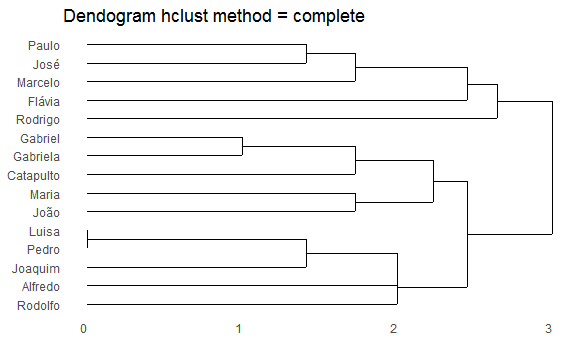

```r
# Implementa o algoritmo hier?rquico e apresenta o dendrograma
hc <- hclust(dist(grede_two_mode), "complete")  # explorar com outros métodos de distância
ggdendrogram(hc, rotate=TRUE,labels = TRUE)  + labs(title = "Dendogram hclust method = complete")
```

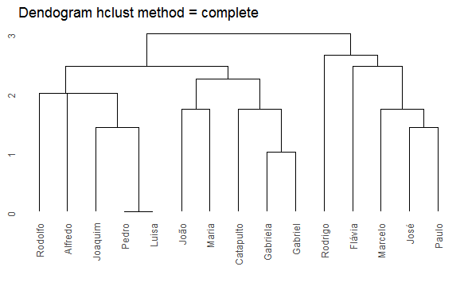

```r
ggdendrogram(hc, rotate=FALSE,labels = TRUE)  + labs(title = "Dendogram hclust method = complete")
```

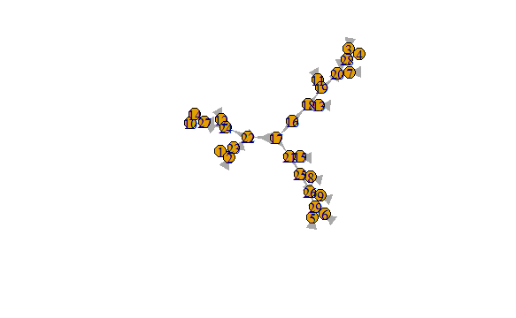

```r
phylo_tree = as.phylo(hc)
graph_edges = phylo_tree$edge
graph_net = graph.edgelist(graph_edges)
plot(graph_net)
```

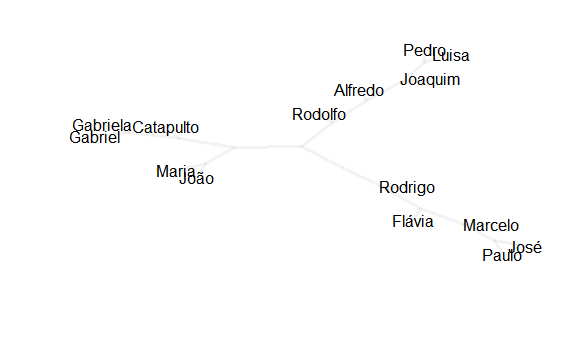

```r
graph_layout = layout.auto(graph_net)
nobs = length(hc$labels)
{
  plot(graph_layout[,1], graph_layout[,2], type = "n", axes = FALSE,
     xlab = "", ylab = "")
  segments(
    x0 = graph_layout[graph_edges[,1],1],
    y0 = graph_layout[graph_edges[,1],2],
    x1 = graph_layout[graph_edges[,2],1],
    y1 = graph_layout[graph_edges[,2],2],
    col = "#dcdcdc55", lwd = 3.5
    )
  text(graph_layout[1:nobs,1], graph_layout[1:nobs,2],
       phylo_tree$tip.label, cex = 1, xpd = TRUE, font = 1)
}
```

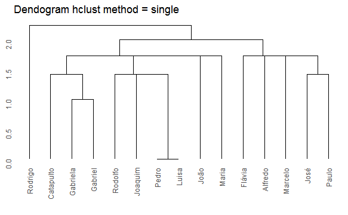

```r
hc_single <- hclust(dist(grede_two_mode), method = "single")
ggdendrogram(hc_single, rotate=FALSE,labels = TRUE) + labs(title = "Dendogram hclust method = single")
```

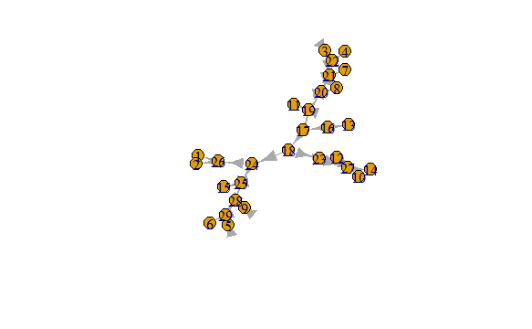

```r
phylo_tree = as.phylo(hc_single)
graph_edges = phylo_tree$edge
graph_net = graph.edgelist(graph_edges)
plot(graph_net)
```

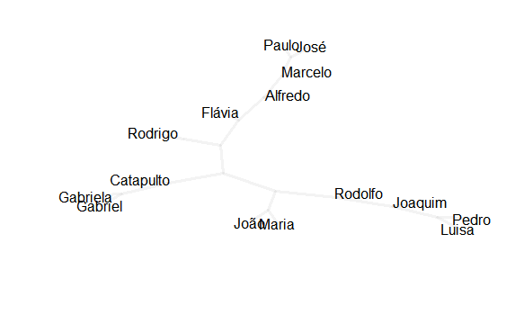

```r
graph_layout = layout.auto(graph_net)
nobs = length(hc_single$labels)
{
  plot(graph_layout[,1], graph_layout[,2], type = "n", axes = FALSE,
     xlab = "", ylab = "")
  segments(
    x0 = graph_layout[graph_edges[,1],1],
    y0 = graph_layout[graph_edges[,1],2],
    x1 = graph_layout[graph_edges[,2],1],
    y1 = graph_layout[graph_edges[,2],2],
    col = "#dcdcdc55", lwd = 3.5
    )
  text(graph_layout[1:nobs,1], graph_layout[1:nobs,2],
       phylo_tree$tip.label, cex = 1, xpd = TRUE, font = 1)
}
```